# fpolisolutions_project_feedback

## CMPINF 2100 - Final project feedback

### FPoliSolutions: Predictive Maintenance

This report gives general feedback based on the proposals about the final project. In addition to addressing pitfalls, multiple recommendations are provided to help with performing the analysis for the project.

## Import Modules

```python
import numpy as np
import pandas as pd
import matplotlib.pyplot as plt

import seaborn as sns
```

## Read data

```python
df = pd.read_csv('training_data.csv')

df.info()
```

```
<class 'pandas.core.frame.DataFrame'>
RangeIndex: 223 entries, 0 to 222
Data columns (total 64 columns):
 #   Column  Non-Null Count  Dtype
---  ------  --------------  -----
 0   X01     223 non-null    float64
 1   X02     223 non-null    float64
 2   X03     223 non-null    float64
 3   X04     223 non-null    float64
 4   X05     223 non-null    float64
 5   X06     223 non-null    float64
 6   X07     223 non-null    float64
 7   X08     223 non-null    float64
 8   X09     223 non-null    float64
 9   X10     223 non-null    float64
```

[output cut: 56 more lines]

## Comments

The columns with names starting with `X`, `Z`, and `V` are the INPUTS to this problem. There are clearly MANY input variables! There is however a simple way to select ALL inputs. You can DROP the output column, `Y`!

```python
df.drop(columns=['Y']).info()
```

```
<class 'pandas.core.frame.DataFrame'>
RangeIndex: 223 entries, 0 to 222
Data columns (total 63 columns):
 #   Column  Non-Null Count  Dtype
---  ------  --------------  -----
 0   X01     223 non-null    float64
 1   X02     223 non-null    float64
 2   X03     223 non-null    float64
 3   X04     223 non-null    float64
 4   X05     223 non-null    float64
 5   X06     223 non-null    float64
 6   X07     223 non-null    float64
 7   X08     223 non-null    float64
 8   X09     223 non-null    float64
 9   X10     223 non-null    float64
```

[output cut: 55 more lines]

This provides a simple way to create an object containing the NAMES of the input columns. The `Y` column can be dropped and the `.columns` attribute can be used to create the LIST of input names!

```python
input_names = df.drop(columns=['Y']).columns
```

```python
input_names
```

```
Index(['X01', 'X02', 'X03', 'X04', 'X05', 'X06', 'X07', 'X08', 'X09', 'X10',
       'X11', 'X12', 'X13', 'X14', 'X15', 'X16', 'X17', 'X18', 'X19', 'X20',
       'X21', 'X22', 'X23', 'X24', 'X25', 'Z01', 'Z02', 'Z03', 'Z04', 'Z05',
       'Z06', 'Z07', 'Z08', 'Z09', 'V01', 'V02', 'V03', 'V04', 'V05', 'V06',
       'V07', 'V08', 'V09', 'V10', 'V11', 'V12', 'V13', 'V14', 'V15', 'V16',
       'V17', 'V18', 'V19', 'V20', 'V21', 'V22', 'V23', 'V24', 'V25', 'V26',
       'V27', 'V28', 'V29'],
      dtype='object')
```

Seaborn wide format plotting options provide a simple and quick way to check if the scales and magnitudes are consistent across the inputs. As shown below a few inputs dominate the scale! One input appears located far from the others and thus that input dominates the magnitude.

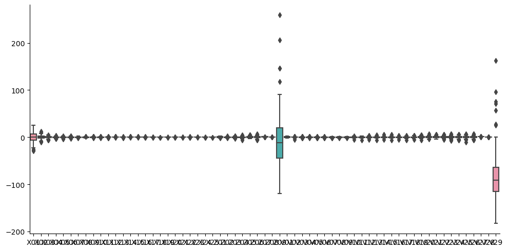

```python
sns.catplot(data = df.drop(columns=['Y']), kind='box', aspect=2)

plt.show()
```

The inputs can then be RESHAPED from WIDE to LONG-FORMAT to enable visualizing inputs via facets. The `input_names` list is used to identify the columns to "gather up" and "stack" into LONG-FORMAT!

```python
lf = df.copy().\
reset_index().\
rename(columns={'index': 'rowid'}).\
melt(id_vars=['rowid', 'Y'], value_vars=input_names, ignore_index=True)
```

```python
lf
```

|  | rowid | Y | variable | value |
| --- | --- | --- | --- | --- |
| 0 | 0 | 1 | X01 | -2.907070 |
| 1 | 1 | 1 | X01 | -4.608052 |
| 2 | 2 | 1 | X01 | 4.338816 |
| 3 | 3 | 0 | X01 | -1.835062 |
| 4 | 4 | 1 | X01 | 13.990969 |
| ... | ... | ... | ... | ... |
| 14044 | 218 | 0 | V29 | -100.512718 |
| 14045 | 219 | 1 | V29 | -118.299085 |
| 14046 | 220 | 1 | V29 | -102.237684 |
| 14047 | 221 | 1 | V29 | -119.015441 |
| 14048 | 222 | 1 | V29 | -78.872248 |

14049 rows × 4 columns

The histograms for all inputs can then be shown within separate facets using Seaborn. Most of the input distributions appear to be quite symmetric though there are several that are ASYMMETRIC. These ASYMMETRIC distributions have tails to the LEFT of the BULK of the observations or to the RIGHT of the BULK of the observations.

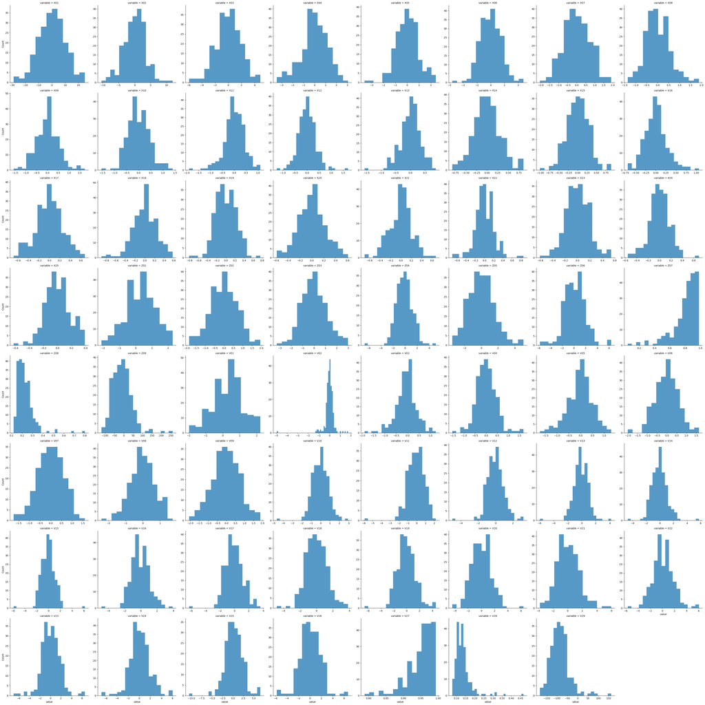

```python
sns.displot(data = lf, x='value', col='variable', kind='hist', col_wrap=8,
            facet_kws={'sharex': False, 'sharey': False},
            common_bins=False)

plt.show()
```

Asymetry or **skewness** cause the MEAN to be different from the MEDIAN. Long tails to higher values "pull" the mean to be greater than the median. Let's calculate the skew for all continuous variables in the data set and plot the skew across variables. As we see below many variables have positive skew values. This is consistent with the histograms because positive skew denotes long tails to the right. Skew close to zero corresponds to symmetric distributions.

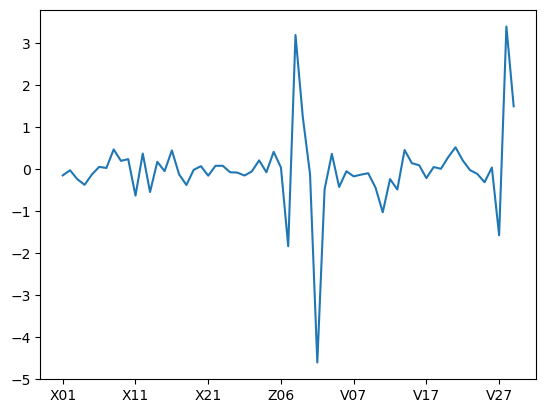

```python
fig, ax = plt.subplots()

df.drop(columns=['Y']).skew().plot(ax=ax)

plt.show()
```

Let's identify all inputs with obvious non-zero skewness. These variables will correspond to skewness greater than 1 in magnitude.

```python
high_skew_inputs = input_names[ np.abs(df.drop(columns=['Y']).skew()) > 1 ]
```

The names of the high skew (positive or negative) inputs are shown below.

```python
high_skew_inputs
```

```
Index(['Z07', 'Z08', 'Z09', 'V02', 'V11', 'V27', 'V28', 'V29'], dtype='object')
```

The histograms for the high magnitude skew inputs are shown below.

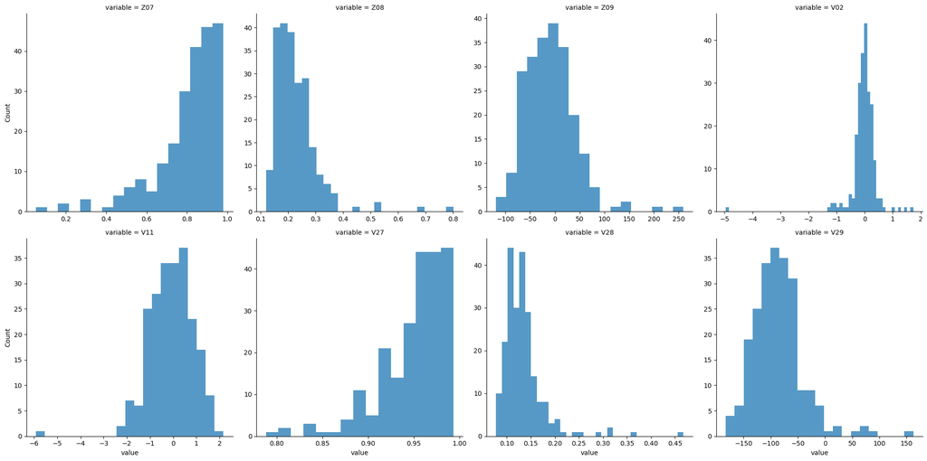

```python
sns.displot(data = lf.loc[ lf.variable.isin( high_skew_inputs ), : ],
            x='value', col='variable', kind='hist', col_wrap=4,
            facet_kws={'sharex': False, 'sharey': False},
            common_bins=False)

plt.show()
```

We can try and remove the skew by applying various transformation functions. Common transformations are the natural log, log base 10, log base 2, the square root, and the inverse (the inverse is 1 divided by the variable). These transformation require that the variable does **not** identically equal zero. So it is good to check if variables equal zero. As shown below, **none** of the variables equal zero!

```python
lf.loc[ (lf.value == 0), :].groupby(['variable']).size()
```

```
Series([], dtype: int64)
```

We must also check if the values are negative because the log and square root transformations cannot be applied to negative values. Multiple high skew variables have negative values!

```python
lf.loc[ (lf.variable.isin(high_skew_inputs)) & (lf.value < 0), :].groupby(['variable']).size()
```

```
variable
V02    110
V11    119
V29    215
Z09    136
dtype: int64
```

As shown below, those 4 inputs do not visually have the most asymetric distributions!

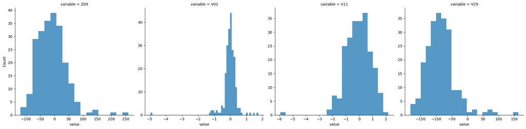

```python
sns.displot(data = lf.loc[ lf.variable.isin( ['V02', 'V11', 'V29', 'Z09'] ), : ],
            x='value', col='variable', kind='hist', col_wrap=4,
            facet_kws={'sharex': False, 'sharey': False},
            common_bins=False)

plt.show()
```

Therefore, for simplicity let's focus on the asymetric positive valued variables. CMPINF 2120 discusses how to remove skew of NEGATIVE valued variables.

```python
lf_skew = lf.loc[ lf.variable.isin(high_skew_inputs), :].copy()

lf_skew = lf_skew.loc[ ~lf_skew.variable.isin(['V02', 'V11', 'V29', 'Z09']), :].copy()
```

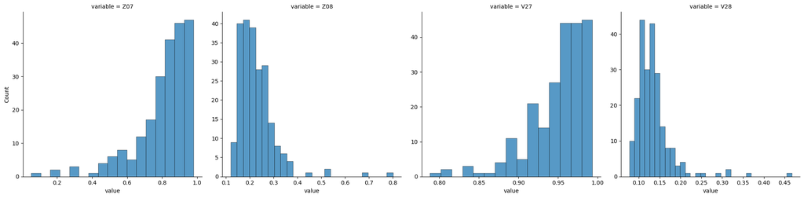

```python
sns.displot(data = lf_skew,
            x='value', col='variable', kind='hist', col_wrap=4,
            facet_kws={'sharex': False, 'sharey': False},
            common_bins=False)

plt.show()
```

One approach to remove SKEW is to apply the natural log transformation. However, as shown below that does not seem to help with these variables!

```python
lf_skew['log_value'] = np.log( lf_skew.value )
```

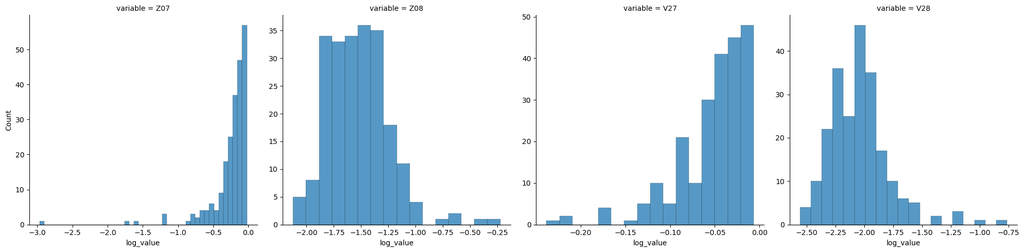

```python
sns.displot(data = lf_skew,
            x='log_value', col='variable', kind='hist', col_wrap=4,
            facet_kws={'sharex': False, 'sharey': False},
            common_bins=False)

plt.show()
```

Instead, we could apply the inverse transformation. This works well for two of the columns but not well for the others!

```python
lf_skew['inverse_value'] = 1 / lf_skew.value
```

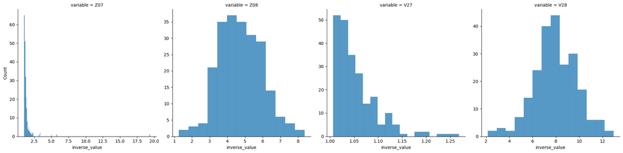

```python
sns.displot(data = lf_skew,
            x='inverse_value', col='variable', kind='hist', col_wrap=4,
            facet_kws={'sharex': False, 'sharey': False},
            common_bins=False)

plt.show()
```

An alternative approach is to apply the square root. This does not seem to help any of the variables!

```python
lf_skew['sqrt_value'] = np.sqrt( lf_skew.value )
```

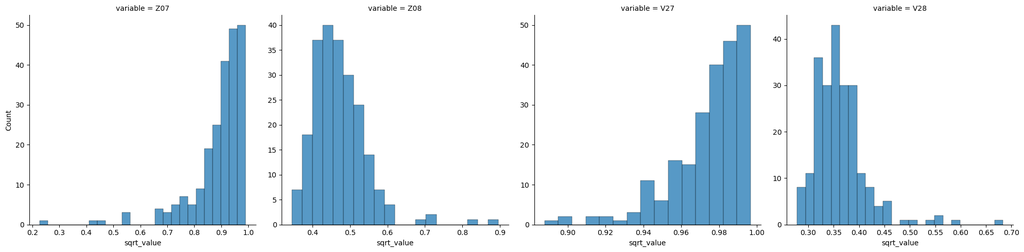

```python
sns.displot(data = lf_skew,
            x='sqrt_value', col='variable', kind='hist', col_wrap=4,
            facet_kws={'sharex': False, 'sharey': False},
            common_bins=False)

plt.show()
```

You might be thinking none of these transformations are perfect. None of these transformations can truly "solve" the problem. You are correct! One definite method does **not** always work for all situtations. This is the reality of modeling! However, there are general approaches that attempt to create an *optimal* transformation to remove skew. Several such approaches are the Box-Cox, Yeo-Johnson, and Quantile transformations. These more advanced procedures are beyond the scope of CMPINF 2100. They are discussed and demonstrated in CMPINF 2120. Therefore, if you continue in the ADDM courses you will see these more advanced **pre-processing** methods.

That said, one approach that does work well for left skewed distributions is to SHIFT the value and then apply the natural log transformation. This style is truly intended for variables for variables with a known upper bound. We do **not** know if there are upper bounds but it seems like the left skewed variables do NOT exceed 1. So, let's subtract the values from 1 and then apply the natural log.

```python
lf_skew['shift_value'] = 1 - lf_skew.value
```

```python
lf_skew['log_shift_value'] = np.log( lf_skew.shift_value )
```

As shown below, the "fake" upper bound procedure works VERY well for the LEFT SKEWED variables! The procedure did NOT work well for the non-left skewed variables. Again, this highlights that certain transformations work well for certain conditions!

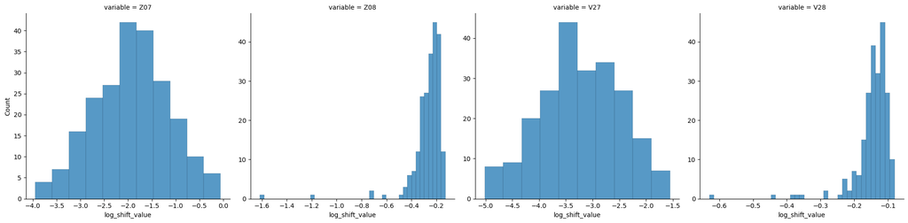

```python
sns.displot(data = lf_skew,
            x='log_shift_value', col='variable', kind='hist', col_wrap=4,
            facet_kws={'sharex': False, 'sharey': False},
            common_bins=False)

plt.show()
```

You should consider applying a transformation to REMOVE the skew to those variables that seem like they are not symmetric. As you've seen here, the transformation you apply depends on if the variable has a tail to the right or left.

The key to this project is PCA because the inputs are so highly correlated. Although we discussed PCA up to this point as a tool to help with visualization and data exploration, PCA can also be used to extract features for models. Thus, PCA can be viewed as a **pre-processing** step for predictive models! This lets the models work with uncorrelated features rather than correlated features. The last few modules will show how to create data analysis pipelines of applying PCA and fitting models with PCA features. However, to get started manually perform PCA and use the PC scores as features to the binary classifiers. Start by performing PCA on the original variables. Then try out various transformation functions on the variables and reperform PCA. Select the number of PCs to use as features in the model based on the standard deviation or variance of the PCs. Keep all PCs that seem to have a meaningful amount of variance, similar to "knee bend" plot in clustering. CMPINF 2120 discusses PCA in much more detail so that you will learn just how to select the appropriate number of PCs.

### Output

The output variable is named `Y`. The output is an INTEGER data type, but the OUTPUT is BINARY! The EVENT is `Y == 1` and the NON-EVENT is `Y == 0`.

```python
df.Y.value_counts()
```

```
1    138
0     85
Name: Y, dtype: int64
```

Thus, you **cannot** use linear models to predict the output! This is a CLASSIFICATION problem! You therefore need to fit logistic regression models to predict the EVENT PROBABILITY as functions of the INPUTS (or PCs preprocessed from the INPUTS).

Pay close attention to the PROPORTION of EVENTS though in the data. The EVENT occurs roughly 62% of the time. Thus, in order for classifiers to be better than "random guessing" the model must have a CLASSIFICATION accuracy greater than 62%!

```python
df.Y.value_counts(normalize=True)
```

```
1    0.618834
0    0.381166
Name: Y, dtype: float64
```